[figure not shown]

# Real World Random Forest

#### Business Problem

Based on a number of factors, a Healthcare organization wants to build a predictive model for Heart Disease. Using determinants like Age, Blood pressure, Chest Pain, Maximum Heart Rate, etc., they would like to identify those with likely Heart Disease for deeper diagnostic testing, lifestyle intervention and potential corrective surgery.

Since there are numerous observable factors (12+) that have historically shown the significant correlation to Heart Disease, the organization will develop a Random Forest model to provide the highest predictive accuracy.

#### Goal

Using an existing dataset of Heart Disease observation, determine the highest accuracy model to predict Heart Disease for new patients where the model features are available.

#### Tools

**R-Studio** with libraries: *tidyverse, randomforest, ggplot2, cowplot*

##### Steps

*1. Import data from UCI machine learning datasets @ http://archive.ics.uci.edu/ml/machine-learning-databases/heart-disease/processed.cleveland.data*

*2. Clean and recode the data features as needed to use for Random Forest modeling*

```
## 'data.frame':    303 obs. of  14 variables:
##  $ Age                  : num  63 67 67 37 41 56 62 57 63 53 ...
##  $ Sex                  : Factor w/ 2 levels "F","M": 2 2 2 2 1 2 1 1 2 2 ...
##  $ ChestPain            : Factor w/ 4 levels "1","2","3","4": 1 4 4 3 2 2 4 4 4 4 ...
##  $ RestingBloodPressure : num  145 160 120 130 130 120 140 120 130 140 ...
##  $ Cholesterol          : num  233 286 229 250 204 236 268 354 254 203 ...
##  $ FastingBloodSugar    : Factor w/ 2 levels "0","1": 2 1 1 1 1 1 1 1 1 2 ...
##  $ RestingECG           : Factor w/ 3 levels "0","1","2": 3 3 3 1 3 1 3 1 3 3 ...
##  $ MaxHeartRate         : num  150 108 129 187 172 178 160 163 147 155 ...
##  $ ExerciseInducedAngina: Factor w/ 2 levels "0","1": 1 2 2 1 1 1 1 2 1 2 ...
##  $ STPostExercise       : num  2.3 1.5 2.6 3.5 1.4 0.8 3.6 0.6 1.4 3.1 ...
##  $ Slope                : Factor w/ 3 levels "1","2","3": 3 2 2 3 1 1 3 1 2 3 ...
##  $ VesselsFlouro        : Factor w/ 4 levels "0","1","2","3": 1 4 3 1 1 1 3 1 2 1 ...
##  $ Thal                 : Factor w/ 3 levels "3","6","7": 2 1 3 1 1 1 1 1 3 3 ...
##  $ HeartDisease         : Factor w/ 2 levels "Healthy","Unhealthy": 1 2 2 1 1 1 2 1 2 2 ...
```

*3. Impute missing values in the dataset usimg a number of random forest iterations and then Model ‘HeartDisease’ from a Forest of 500 Random Trees using all features from the dataset*

```
## ntree      OOB      1      2
##   300:  17.49% 12.80% 23.02%
## ntree      OOB      1      2
##   300:  16.83% 14.02% 20.14%
## ntree      OOB      1      2
##   300:  17.82% 13.41% 23.02%
## ntree      OOB      1      2
##   300:  17.49% 14.02% 21.58%
## ntree      OOB      1      2
##   300:  17.16% 12.80% 22.30%
## ntree      OOB      1      2
##   300:  18.15% 14.63% 22.30%
```

```
##
## Call:
##  randomForest(formula = HeartDisease ~ ., data = data_imputed,      proximity = TRUE)
##                Type of random forest: classification
##                      Number of trees: 500
## No. of variables tried at each split: 3
##
##         OOB estimate of  error rate: 16.83%
## Confusion matrix:
##           Healthy Unhealthy class.error
## Healthy       142        22   0.1341463
## Unhealthy      29       110   0.2086331
```

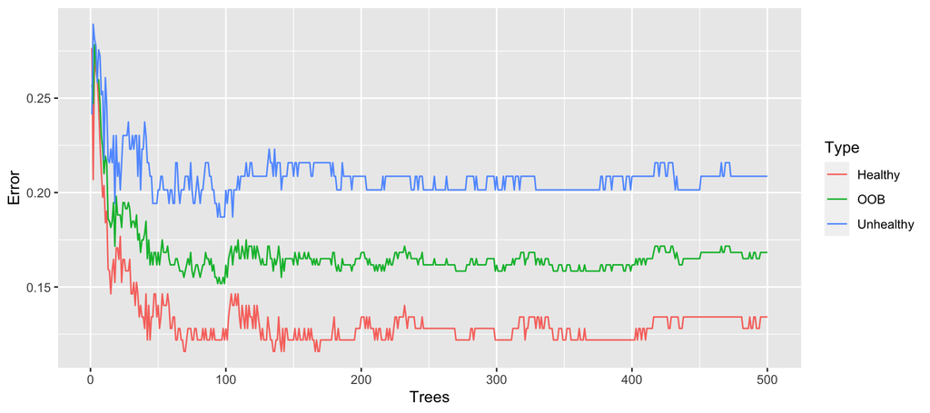

*5. We can review the plot and see if we are in fact lowering our error rate as more trees are evaluated byt the model.*

*Here, The BLUE line represents our error rate when classifying Unhealthy patients, the RED line our error rate when classifying Healthy patients and the GREEN line is the overall OOB error rate.*

*6. We can rerun the model with more trees and also experiment with the number of variables used at each internal node split.*

```
##
## Call:
##  randomForest(formula = HeartDisease ~ ., data = data_imputed,      ntree = 1000, proximity = TRUE)
##                Type of random forest: classification
##                      Number of trees: 1000
## No. of variables tried at each split: 3
##
##         OOB estimate of  error rate: 17.16%
## Confusion matrix:
##           Healthy Unhealthy class.error
## Healthy       141        23   0.1402439
## Unhealthy      29       110   0.2086331
```

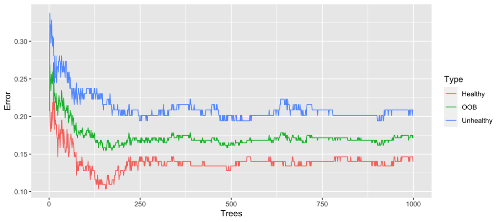

*Notice the OOB error rate for the 1000 tree model is actually higher than the 500 tree model. Also I tried adding additonal variables at each node step and doing so did not improve the accuracy in this particular case.*

Go Back